# Predicting the Denver Housing Market

### John Francis Ryan (jfryan70@gmail.com)

# Part Four: What Explains Neighborhood Housing values?

## Dealing with Missing Values

Now you shift gears and begin to explore variations in the housing market. Why do some neighborhoods have more expensive houses than others?

Before going ahead, it is important to prepare the data. One problem with the data pertains to missing values. As seen previously, nine census tracts do not have a median housing value and thus you must remove them from the dataset prior to begining the analysis.

```r
#################################
#

setwd('C:/Users/John/Denver_Housing_Project/ACS_Data/Final_Data')

load("ACSData9_14.RData")

# Identify and remove missing values from analysis

table(is.na(ACSData9_14$MedHouseVal))
```

```
##
## FALSE  TRUE
##   578     9
```

```r
# Noticing ten missing observations of median housing value, and taking out
test <- subset(ACSData9_14, is.na(MedHouseVal)) # So you can look at the 2 observations missing this variable
ACSData9_14nona <- subset(ACSData9_14, !is.na(MedHouseVal))
table(is.na(ACSData9_14nona$MedHouseVal)) #Now no NA's in median housing value
```

```
##
## FALSE
##   578
```

## Narrowing and Splitting the Data

First, you include two of three household income groupings, one to represent upper-class household income (above $100K) and another for middle-class income ($35 to $100K). In this way, you include the most interesting groups while keeping the lower-class income group out as a control. You choose not to include more specific groups (e.g. percent $35 to $50K) both to reduce multicollinearity and provide a more general story about income groups. You are curious to explore the surprising alleged negative link between middle-class income and housing values. You also include median individual (as opposed to household) income to tap into non-family housing and non-houseowners in general.

Second, you include two of three basic education groups, one for high-school dropouts and another for college graduates (and above); high school-only graduates remain as a control group. You suspect a negative relationship between high school dropout percentage and housing values, and a positive one for college graduates and housing values.

Third, you look at a few other family demographics. First, you include the percentage of households as married-couple families, expecting a positive relationship. Second, you include average household family size to explore whether it affects housing values. Third, you investigate whether ‘older’ neighborhoods - here, median age in the neighborhood - tend to affect housing values.

Fourth, you include a few indicators for the overall neighborhood economy. First, is it true that vacancies in the neighborhood depress its overall economic value? You include the percentage of building vacancies to tap into this. Second, since you believe neighborhood poverty affects potential buyers you include the percentage of people living below 150% of the poverty level (as defined by the Census). You also include the average number of hours worked.

Last, you decide to investigate further whether school quality still has an impact on housing values.

With these in mind, you subset the initial dataset of 120+ variables to only those of interest.

Of course, one of the problems in any statistical analysis is overfitting the data. If your algorithm is too complicated, it is practically useless in another context. A fun example for presidential elections is this [XKCD comic](https://xkcd.com/1122).

```r
# Now, to test models using regression

library(corrplot)
library(foreign)
library(glmnet)
library(broom)
library(foreign)
library(MASS)
library(car)
library(ggplot2)

ACSData9_14nona.mod <-ACSData9_14nona[c("MedHouseVal",
                  "HHInc_Own_PercUnder35K",
                  "HHInc_Own_Perc35Kto100K",
                  "HHInc_Own_PercOver100K",
                  "IndInc_Median",
                  "PercNotHSGrad",
                  "PercBAorMore",
                  "HHs_Perc_MarriedCplFam",
                  "HHs_AvgFamilySize",
                  "MedianAge",
                  "PercUnder150PercPov",
                  "Housing_Perc_Vacant",
                  "MeanHrsWkd",
                  "SchlDistRnkLYr")]
```

In order to avoid potential overfitting, you then split up the data into two datasets - one to design (or ‘train’) a statistical model, the other, to test the effectiveness of said model on new data. If the training model performs poorly on the test dataset, it is time to go back to the drawing board!

```r
# Create a training/test split of 70% train, 30% test

set.seed(1234)
ind <-sample(2,nrow(ACSData9_14nona.mod), replace=TRUE, prob=c(0.7, 0.3))
ACSData9_14nona.mod.train <-ACSData9_14nona.mod[ind==1,]
ACSData9_14nona.mod.test <-ACSData9_14nona.mod[ind==2,]

table(is.na(ACSData9_14nona.mod.train$MedHouseVal)) # 400 observations
```

```
##
## FALSE
##   400
```

```r
table(is.na(ACSData9_14nona.mod.test$MedHouseVal)) # 178 observations
```

```
##
## FALSE
##   178
```

```r
save(ACSData9_14nona, file = "ACSData9_14nona.RData")
save(ACSData9_14nona.mod, file = "ACSData9_14nona.mod.RData")
save(ACSData9_14nona.mod.train, file = "ACSData9_14nona.mod.training.RData")
save(ACSData9_14nona.mod.test, file = "ACSData9_14nona.mod.test.RData")
```

## Analysis: Regression

Now that you have narrowed down and split the data, you can begin to analyze the data. You begin with linear regression for a variety of reasons: it is simple, familiar, and easy to interpret the results.

### Initial Results

So, which ones will remain influential? Let’s see!

```r
# Modeling using OLS first

model1 <- lm(MedHouseVal ~
                  HHInc_Own_Perc35Kto100K +
                  HHInc_Own_PercOver100K +
                  IndInc_Median +
                  PercNotHSGrad +
                  PercBAorMore +
                  HHs_Perc_MarriedCplFam +
                  HHs_AvgFamilySize +
                  MedianAge +
                  PercUnder150PercPov +
                  Housing_Perc_Vacant +
                  MeanHrsWkd +
                  SchlDistRnkLYr,
                  data = ACSData9_14nona.mod.train)

# make predictions and summarize accuracy
predictions1 <- predict(model1, ACSData9_14nona.mod.train)

model1.res = resid(model1)
summary(model1)
```

```
##
## Call:
## lm(formula = MedHouseVal ~ HHInc_Own_Perc35Kto100K + HHInc_Own_PercOver100K +
##     IndInc_Median + PercNotHSGrad + PercBAorMore + HHs_Perc_MarriedCplFam +
##     HHs_AvgFamilySize + MedianAge + PercUnder150PercPov + Housing_Perc_Vacant +
##     MeanHrsWkd + SchlDistRnkLYr, data = ACSData9_14nona.mod.train)
##
## Residuals:
##     Min      1Q  Median      3Q     Max
## -150977  -36596   -3715   28779  454435
##
## Coefficients:
##                           Estimate Std. Error t value Pr(>|t|)
## (Intercept)              39798.969 111611.260   0.357  0.72160
## HHInc_Own_Perc35Kto100K    464.897    622.065   0.747  0.45531
## HHInc_Own_PercOver100K    4770.929    630.784   7.563 2.88e-13 ***
## IndInc_Median                1.714      0.802   2.137  0.03322 *
## PercNotHSGrad             1576.685    754.130   2.091  0.03720 *
## PercBAorMore              2488.800    475.519   5.234 2.73e-07 ***
## HHs_Perc_MarriedCplFam     134.468    440.238   0.305  0.76019
## HHs_AvgFamilySize        -2279.494  16950.911  -0.134  0.89310
## MedianAge                 3401.353    746.543   4.556 6.99e-06 ***
## PercUnder150PercPov       1694.343    637.435   2.658  0.00818 **
## Housing_Perc_Vacant       1692.105   1020.686   1.658  0.09817 .
## MeanHrsWkd               -7545.172   2349.647  -3.211  0.00143 **
## SchlDistRnkLYr          -37782.364  21445.037  -1.762  0.07889 .
## ---
## Signif. codes:  0 '***' 0.001 '**' 0.01 '*' 0.05 '.' 0.1 ' ' 1
##
## Residual standard error: 66860 on 387 degrees of freedom
## Multiple R-squared:  0.7673, Adjusted R-squared:  0.7601
## F-statistic: 106.3 on 12 and 387 DF,  p-value: < 2.2e-16
```

```r
AIC(model1)
```

```
## [1] 10038.21
```

```r
BIC(model1)
```

```
## [1] 10094.09
```

```r
summary(model1.res)
```

```
##    Min. 1st Qu.  Median    Mean 3rd Qu.    Max.
## -151000  -36600   -3715       0   28780  454400
```

```r
#ggplot(model1.res)
sm <-summary(model1)
sum(sm$residuals^2)
```

```
## [1] 1.729949e+12
```

```r
sqrt(mean(sm$residuals^2))
```

```
## [1] 65763.77
```

```r
vif(model1)
```

```
## HHInc_Own_Perc35Kto100K  HHInc_Own_PercOver100K           IndInc_Median
##                5.963890               12.977635                8.542038
##           PercNotHSGrad            PercBAorMore  HHs_Perc_MarriedCplFam
##                7.456036                8.124318                5.483892
##       HHs_AvgFamilySize               MedianAge     PercUnder150PercPov
##                4.925340                2.304929                8.339146
##     Housing_Perc_Vacant              MeanHrsWkd          SchlDistRnkLYr
##                1.238618                1.964592                1.757964
```

You notice a few things from the results above. First, the explanatory power of the model is robust, with an adjusted R-squared of 0.76. (Keep in mind the residual standard error of 65,763 for later.) You also notice more than one coefficient is in a direction opposite to what you expected.

For now, you are concerned about multicollinearity: the variance inflation factor (VIF) scores are high in some cases.

You decide to run a few models with all variables but one, to see the potential impact of related variables.

```r
model2 <- lm(MedHouseVal ~
                  HHInc_Own_Perc35Kto100K +
                  HHInc_Own_PercOver100K +
                  IndInc_Median +
                  PercBAorMore +
                  HHs_Perc_MarriedCplFam +
                  HHs_AvgFamilySize +
                  MedianAge +
                  PercUnder150PercPov +
                  Housing_Perc_Vacant +
                  MeanHrsWkd +
                  SchlDistRnkLYr,
                  data = ACSData9_14nona.mod.train)

# make predictions and summarize accuracy
predictions2 <- predict(model2, ACSData9_14nona.mod.train)

model2.res = resid(model2)
summary(model2)
```

```
##
## Call:
## lm(formula = MedHouseVal ~ HHInc_Own_Perc35Kto100K + HHInc_Own_PercOver100K +
##     IndInc_Median + PercBAorMore + HHs_Perc_MarriedCplFam + HHs_AvgFamilySize +
##     MedianAge + PercUnder150PercPov + Housing_Perc_Vacant + MeanHrsWkd +
##     SchlDistRnkLYr, data = ACSData9_14nona.mod.train)
##
## Residuals:
##     Min      1Q  Median      3Q     Max
## -152865  -37972   -3262   26635  461249
##
## Coefficients:
##                           Estimate Std. Error t value Pr(>|t|)
## (Intercept)              2.345e+04  1.118e+05   0.210  0.83397
## HHInc_Own_Perc35Kto100K  2.217e+02  6.137e+02   0.361  0.71811
## HHInc_Own_PercOver100K   4.638e+03  6.303e+02   7.359 1.12e-12 ***
## IndInc_Median            1.922e+00  7.992e-01   2.405  0.01665 *
## PercBAorMore             2.202e+03  4.572e+02   4.815 2.11e-06 ***
## HHs_Perc_MarriedCplFam   1.129e+02  4.420e+02   0.255  0.79854
## HHs_AvgFamilySize        1.214e+04  1.555e+04   0.781  0.43541
## MedianAge                3.626e+03  7.420e+02   4.887 1.50e-06 ***
## PercUnder150PercPov      2.354e+03  5.562e+02   4.232 2.89e-05 ***
## Housing_Perc_Vacant      1.792e+03  1.024e+03   1.750  0.08087 .
## MeanHrsWkd              -7.759e+03  2.358e+03  -3.291  0.00109 **
## SchlDistRnkLYr          -4.858e+04  2.090e+04  -2.324  0.02065 *
## ---
## Signif. codes:  0 '***' 0.001 '**' 0.01 '*' 0.05 '.' 0.1 ' ' 1
##
## Residual standard error: 67150 on 388 degrees of freedom
## Multiple R-squared:  0.7647, Adjusted R-squared:  0.758
## F-statistic: 114.6 on 11 and 388 DF,  p-value: < 2.2e-16
```

```r
AIC(model2)
```

```
## [1] 10040.7
```

```r
BIC(model2)
```

```
## [1] 10092.59
```

```r
summary(model2.res)
```

```
##    Min. 1st Qu.  Median    Mean 3rd Qu.    Max.
## -152900  -37970   -3262       0   26630  461200
```

```r
vif(model2)
```

```
## HHInc_Own_Perc35Kto100K  HHInc_Own_PercOver100K           IndInc_Median
##                5.755385               12.846682                8.410466
##            PercBAorMore  HHs_Perc_MarriedCplFam       HHs_AvgFamilySize
##                7.446810                5.480881                4.109758
##               MedianAge     PercUnder150PercPov     Housing_Perc_Vacant
##                2.257227                6.295525                1.235892
##              MeanHrsWkd          SchlDistRnkLYr
##                1.960872                1.656039
```

```r
model3 <- lm(MedHouseVal ~
                  HHInc_Own_Perc35Kto100K +
                  HHInc_Own_PercOver100K +
                  IndInc_Median +
                  PercNotHSGrad +
                  PercBAorMore +
                  HHs_Perc_MarriedCplFam +
                  HHs_AvgFamilySize +
                  MedianAge +
                  PercUnder150PercPov +
                  Housing_Perc_Vacant +
                  SchlDistRnkLYr,
                  data = ACSData9_14nona.mod.train)

# make predictions and summarize accuracy
predictions3 <- predict(model3, ACSData9_14nona.mod.train)

model3.res = resid(model3)
summary(model3)
```

```
##
## Call:
## lm(formula = MedHouseVal ~ HHInc_Own_Perc35Kto100K + HHInc_Own_PercOver100K +
##     IndInc_Median + PercNotHSGrad + PercBAorMore + HHs_Perc_MarriedCplFam +
##     HHs_AvgFamilySize + MedianAge + PercUnder150PercPov + Housing_Perc_Vacant +
##     SchlDistRnkLYr, data = ACSData9_14nona.mod.train)
##
## Residuals:
##     Min      1Q  Median      3Q     Max
## -136135  -38164   -4932   28881  439022
##
## Coefficients:
##                           Estimate Std. Error t value Pr(>|t|)
## (Intercept)             -2.088e+05  8.135e+04  -2.567   0.0106 *
## HHInc_Own_Perc35Kto100K  2.660e+02  6.264e+02   0.425   0.6714
## HHInc_Own_PercOver100K   4.547e+03  6.344e+02   7.168 3.88e-12 ***
## IndInc_Median            2.476e-01  6.671e-01   0.371   0.7107
## PercNotHSGrad            1.682e+03  7.624e+02   2.206   0.0280 *
## PercBAorMore             2.922e+03  4.614e+02   6.334 6.62e-10 ***
## HHs_Perc_MarriedCplFam   5.187e+02  4.287e+02   1.210   0.2271
## HHs_AvgFamilySize       -4.469e+03  1.714e+04  -0.261   0.7944
## MedianAge                3.216e+03  7.532e+02   4.269 2.47e-05 ***
## PercUnder150PercPov      1.655e+03  6.449e+02   2.565   0.0107 *
## Housing_Perc_Vacant      1.789e+03  1.032e+03   1.733   0.0839 .
## SchlDistRnkLYr          -3.455e+04  2.168e+04  -1.594   0.1118
## ---
## Signif. codes:  0 '***' 0.001 '**' 0.01 '*' 0.05 '.' 0.1 ' ' 1
##
## Residual standard error: 67660 on 388 degrees of freedom
## Multiple R-squared:  0.7611, Adjusted R-squared:  0.7543
## F-statistic: 112.4 on 11 and 388 DF,  p-value: < 2.2e-16
```

```r
AIC(model3)
```

```
## [1] 10046.73
```

```r
BIC(model3)
```

```
## [1] 10098.62
```

```r
summary(model3.res)
```

```
##    Min. 1st Qu.  Median    Mean 3rd Qu.    Max.
## -136100  -38160   -4932       0   28880  439000
```

```r
#ggplot(model1.res)
vif(model3)
```

```
## HHInc_Own_Perc35Kto100K  HHInc_Own_PercOver100K           IndInc_Median
##                5.904739               12.819325                5.772992
##           PercNotHSGrad            PercBAorMore  HHs_Perc_MarriedCplFam
##                7.441917                7.469244                5.078865
##       HHs_AvgFamilySize               MedianAge     PercUnder150PercPov
##                4.917370                2.291101                8.335991
##     Housing_Perc_Vacant          SchlDistRnkLYr
##                1.237539                1.754086
```

```r
model4 <- lm(MedHouseVal ~
                  HHInc_Own_PercOver100K +
                  IndInc_Median +
                  PercNotHSGrad +
                  PercBAorMore +
                  HHs_Perc_MarriedCplFam +
                  HHs_AvgFamilySize +
                  MedianAge +
                  PercUnder150PercPov +
                  Housing_Perc_Vacant +
                  MeanHrsWkd +
                  SchlDistRnkLYr,
                  data = ACSData9_14nona.mod.train)


# make predictions and summarize accuracy
predictions4 <- predict(model4, ACSData9_14nona.mod.train)

model4.res = resid(model4)
summary(model4)
```

```
##
## Call:
## lm(formula = MedHouseVal ~ HHInc_Own_PercOver100K + IndInc_Median +
##     PercNotHSGrad + PercBAorMore + HHs_Perc_MarriedCplFam + HHs_AvgFamilySize +
##     MedianAge + PercUnder150PercPov + Housing_Perc_Vacant + MeanHrsWkd +
##     SchlDistRnkLYr, data = ACSData9_14nona.mod.train)
##
## Residuals:
##     Min      1Q  Median      3Q     Max
## -147900  -37188   -3459   29627  454426
##
## Coefficients:
##                          Estimate Std. Error t value Pr(>|t|)
## (Intercept)             7.085e+04  1.035e+05   0.684  0.49419
## HHInc_Own_PercOver100K  4.423e+03  4.253e+02  10.399  < 2e-16 ***
## IndInc_Median           1.758e+00  7.993e-01   2.199  0.02847 *
## PercNotHSGrad           1.471e+03  7.404e+02   1.987  0.04761 *
## PercBAorMore            2.459e+03  4.736e+02   5.193 3.35e-07 ***
## HHs_Perc_MarriedCplFam  1.247e+02  4.398e+02   0.283  0.77697
## HHs_AvgFamilySize      -9.537e+02  1.685e+04  -0.057  0.95489
## MedianAge               3.256e+03  7.205e+02   4.520 8.24e-06 ***
## PercUnder150PercPov     1.602e+03  6.250e+02   2.563  0.01075 *
## Housing_Perc_Vacant     1.715e+03  1.020e+03   1.682  0.09335 .
## MeanHrsWkd             -7.370e+03  2.337e+03  -3.154  0.00173 **
## SchlDistRnkLYr         -3.686e+04  2.140e+04  -1.723  0.08577 .
## ---
## Signif. codes:  0 '***' 0.001 '**' 0.01 '*' 0.05 '.' 0.1 ' ' 1
##
## Residual standard error: 66820 on 388 degrees of freedom
## Multiple R-squared:  0.767,  Adjusted R-squared:  0.7604
## F-statistic: 116.1 on 11 and 388 DF,  p-value: < 2.2e-16
```

```r
AIC(model4)
```

```
## [1] 10036.79
```

```r
BIC(model4)
```

```
## [1] 10088.68
```

```r
summary(model4.res)
```

```
##    Min. 1st Qu.  Median    Mean 3rd Qu.    Max.
## -147900  -37190   -3459       0   29630  454400
```

```r
#ggplot(model1.res)

vif(model4)
```

```
## HHInc_Own_PercOver100K          IndInc_Median          PercNotHSGrad
##               5.907046               8.496246               7.195363
##           PercBAorMore HHs_Perc_MarriedCplFam      HHs_AvgFamilySize
##               8.068867               5.479024               4.871394
##              MedianAge    PercUnder150PercPov    Housing_Perc_Vacant
##               2.149341               8.025484               1.237485
##             MeanHrsWkd         SchlDistRnkLYr
##               1.945107               1.752106
```

[figure not shown]

```r
library(corrgram)
corrgram(ACSData9_14nona.mod.train, order=NULL,
         lower.panel=panel.shade,
         upper.panel=NULL,
         text.panel=panel.txt,
         main="Correlogram of data")
```

### Multicollinearity

You notice from the correlogram above that there is some collinearity between the variables. This should come as little surprise among some of them.

Just to be sure, you run a few slightly-similar models but dropping one variable. The first model, dropping the high-school dropouts factor, does not affect the model greatly but does flip the sign of the average family size factor. The second model, dropping only the average hours worked factor, does change the direction of the intercept. The third, dropping the percentage of household owners $35 to $100K, finds little movement among the remaining variables. More importantly, however, you notice the high VIF scores among some variables within these models. How can you have confidence in your modeling, with such difficulties?

## Multicollinearity and LASSO Regression

Given the rather high level of collinearity among variables, you decide to use LASSO regression. With this method, you can run the original model while introducing a ‘penalty’ for collinearity among variables. Taken from a different perspective, it uses a “tuning parameter” to adjust the model. A good resource is [the first LASSO paper](http://statweb.stanford.edu/~tibs/lasso/lasso.pdf).

Some people might choose to use the one-standard-error lambda, which “err[s] on the side of parsimony” (Hastie T, Tibshirani R, Friedman J, *The Elements of Statistical Learning: Prediction, Inference and Data Mining,* 2nd edition (2009)). However, because you are seeking a model straddling both parsimony and predictive power, you opt for the lambda that provides the lowest mean squared error.

Let us see what happens!

```r
############################
#
#
#  Try LASSO regression to reduce multicollinearity

# Preparing matrices for modeling
# We include a -1 at the end of x.train and x.test, to drop a duplicate intercept term
set.seed(1111)
x.train=model.matrix(MedHouseVal ~
                  HHInc_Own_Perc35Kto100K +
                  HHInc_Own_PercOver100K +
                  IndInc_Median +
                  PercNotHSGrad +
                  PercBAorMore +
                  HHs_Perc_MarriedCplFam +
                  HHs_AvgFamilySize +
                  MedianAge +
                  PercUnder150PercPov +
                  Housing_Perc_Vacant +
                  MeanHrsWkd +
                  SchlDistRnkLYr
                  - 1,
                  data = ACSData9_14nona.mod.train)


y.train=ACSData9_14nona.mod.train$MedHouseVal

x.test=model.matrix(MedHouseVal ~
                  HHInc_Own_Perc35Kto100K +
                  HHInc_Own_PercOver100K +
                  IndInc_Median +
                  PercNotHSGrad +
                  PercBAorMore +
                  HHs_Perc_MarriedCplFam +
                  HHs_AvgFamilySize +
                  MedianAge +
                  PercUnder150PercPov +
                  Housing_Perc_Vacant +
                  MeanHrsWkd +
                  SchlDistRnkLYr
                  - 1,
                  data = ACSData9_14nona.mod.test)

# Performing lasso, with cross-validation, ten folds (default; can choose more)
set.seed(1111)
fit.lasso=cv.glmnet(x.train,y.train,alpha=1)

# Discovering the best lambda, using minimum (not one-standard-error)
```

Here are the coefficients for the ‘one-standard-error’ rule:

```r
coef(fit.lasso, s = "lambda.1se")
```

```
## 13 x 1 sparse Matrix of class "dgCMatrix"
##                                   1
## (Intercept)             118195.7886
## HHInc_Own_Perc35Kto100K  -1405.1613
## HHInc_Own_PercOver100K    2922.3311
## IndInc_Median                .
## PercNotHSGrad                .
## PercBAorMore              1929.3815
## HHs_Perc_MarriedCplFam       .
## HHs_AvgFamilySize            .
## MedianAge                  798.8949
## PercUnder150PercPov          .
## Housing_Perc_Vacant        640.7504
## MeanHrsWkd                   .
## SchlDistRnkLYr               .
```

Here are the coefficients for the minimum lambda rule:

```r
coef(fit.lasso, s = "lambda.min")
```

```
## 13 x 1 sparse Matrix of class "dgCMatrix"
##                                     1
## (Intercept)              64950.142779
## HHInc_Own_Perc35Kto100K      .
## HHInc_Own_PercOver100K    4408.521230
## IndInc_Median                1.454959
## PercNotHSGrad             1457.611863
## PercBAorMore              2433.601997
## HHs_Perc_MarriedCplFam      40.311555
## HHs_AvgFamilySize            .
## MedianAge                 3061.564047
## PercUnder150PercPov       1300.540203
## Housing_Perc_Vacant       1659.476733
## MeanHrsWkd               -6587.240169
## SchlDistRnkLYr          -31366.467912
```

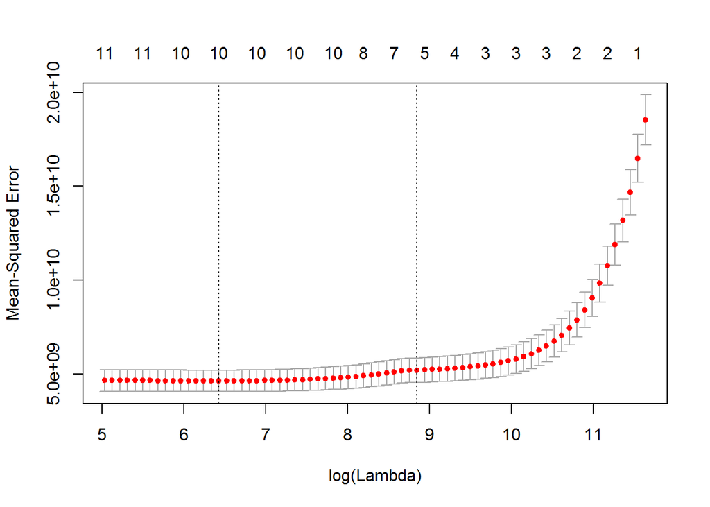

```r
plot(fit.lasso,xvar="lambda",label=TRUE)
```

For the sake of interest, you also plot the change in coefficients as the tuning parameter changes.

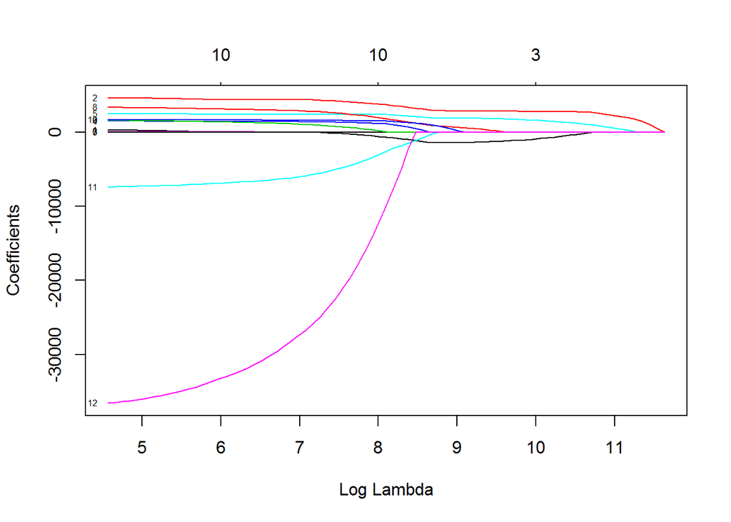

```r
plot(fit.lasso$glmnet.fit, "lambda", label=TRUE)
```

What do you see so far? Probably the largest thing naturally, is the change in the number of coefficients. The model with the one-standard-error has fewer ones, in particular. Since you are searching for both parsimony and low error, you stick with the less-parsimonious model.

## Comparing OLS and LASSO Results

How well does this perform against OLS, however? You calculate a common metric: the root mean-squared error (RMSE). This gives an indication of the model’s performance: how much does it make prediction errors?

```r
bestlamb.lasso <- fit.lasso$lambda.min
bestlamb.lasso
```

```
## [1] 617.0548
```

```r
pred.lasso <-predict(fit.lasso, s=bestlamb.lasso, newx=x.train)
lasso.err <-mean((ACSData9_14nona.mod.train$MedHouseVal-pred.lasso)^2)
sqrt(lasso.err)
```

```
## [1] 65880.98
```

```r
# Check coefficients and RMSE with test data
reg.lasso <-cv.glmnet(x.train,y.train, alpha=1)
pred.lasso2 <-predict(reg.lasso, s=bestlamb.lasso, newx=x.test)
lasso.err2 <-mean((ACSData9_14nona.mod.test$MedHouseVal-pred.lasso2)^2)
coef.lasso2 <-predict(reg.lasso, type="coefficients", s=bestlamb.lasso)
coef.lasso2
```

```
## 13 x 1 sparse Matrix of class "dgCMatrix"
##                                     1
## (Intercept)              64950.142779
## HHInc_Own_Perc35Kto100K      .
## HHInc_Own_PercOver100K    4408.521230
## IndInc_Median                1.454959
## PercNotHSGrad             1457.611863
## PercBAorMore              2433.601997
## HHs_Perc_MarriedCplFam      40.311555
## HHs_AvgFamilySize            .
## MedianAge                 3061.564047
## PercUnder150PercPov       1300.540203
## Housing_Perc_Vacant       1659.476733
## MeanHrsWkd               -6587.240169
## SchlDistRnkLYr          -31366.467912
```

```r
sqrt(lasso.err2)
```

```
## [1] 70766.87
```

## Results

You find that family and personal demographics have a mixed effect (at best) upon housing values. The percent of married couples does appear positive but very small, with a $1,200 difference occurring with a 30 percentage point difference between neighborhoods. This suggests a very weak, positive effect. The average family size appears to wash out in the LASSO model. The model also finds a negative relationship with the average number of hours worked: for every one more hour worked, the neighborhood value decreases by $6,587. Last, the median neighborhood population age appears to have a positive effect: one can find a $45,915 housing value difference between two neighborhoods with a 15 year age difference. Perhaps this is due, in part, to an unspoken minimum age needed to purchase a house: how many 18-year olds can normally qualify for a house loan?

# Conclusion

What can you take away from this? Perhaps the largest is the importance of income and education, with household and individual income affecting housing values directly. Thus, if you want to know where to find top-level housing, it helps to know not simply the wealthy areas but also the areas with the greatest concentration of highly-educated people.

Something else you consider is how to take some modeling with a grain of salt. You noticed school district rankings having a negative impact, but given the marginal significance level and your own thoughts - using a multi-neighborhood variable to explain neighborhood-level fluctuations - you consider the findings inconclusive for now. You have similar thoughts about the vacancy factor, since the OLS models find it to be marginal.

A few things you consider exploring. Why might the results suggest a neighborhood’s high school dropout rate to increase housing values, and the same for poverty rates and housing? That is something to explore later.